# Assignment 03 - Text Mining

Author

Norma Marshall

```r
library(tidyverse)
library(tidytext)
library(readr)
library(textdata)
library(knitr)
```

# Text Mining

A new dataset has been added to the data science data repository https://github.com/USCbiostats/data-science-data/tree/master/03_pubmed. The dataset contains 3,241 abstracts from articles collected via 5 PubMed searches. The search terms are listed in the second column, term and these will serve as the “documents.” Your job is to analyse these abstracts to find interesting insights.

```r
abstracts <- read_csv("pubmed.csv")

head(abstracts) #just for a quick glance of the data
```

```
# A tibble: 6 × 2
  abstract                                                                 term
  <chr>                                                                    <chr>
1 "Background and aims: Many patients with coronavirus disease 2019 (COVI… covid
2 "Introduction: Contradictory data have been reported on the incidence o… covid
3 "This article aims at collecting all information needed for dentists re… covid
4 "OBJECTIVE. The objective of our study was to determine the misdiagnosi… covid
5 "Background: Much of the focus regarding the global pandemic of coronav… covid
6 "The World Health Organization (WHO) has issued a warning that, althoug… covid
```

1. Tokenize the abstracts and count the number of each token. Do you see anything interesting? Does removing stop words change what tokens appear as the most frequent? What are the 5 most common tokens for each search term after removing stopwords?

Without grouping by search term, the top 10 search terms are stop words except for “covid” and “19”, revealing its importance in recent years of research, possibly across search term.

Without removing stopwords the most common words are stop words except for covid and 19 within each term. This may reveal that papers covid-19 were the most common among the 5 different PubMed searchers. After removing stopword, the trend continues with “covid” and “19” being the top 2 search terms. The rest of the top 10 search terms are related to search terms “prostate”, “cancer”, “pre”, “eclampsia”, “preeclampsia” and terms related to maternal health such as “women” and “pregnancy”.

After reviewing the top 5 words per search term (table above) , the tokens are all related directly to the serach term themselves. For example the top 2 terms related to cystic fibrosis are “cystic” and “fibrosis”

```r
# top words overall regardles of search term
abstracts %>%
  unnest_tokens(word, abstract) %>%
  count(word, sort=TRUE)
```

```
# A tibble: 20,567 × 2
   word      n
   <chr> <int>
 1 the   28126
 2 of    24760
 3 and   19993
 4 in    14653
 5 to    10920
 6 a      8245
 7 with   8038
 8 covid  7275
 9 19     7080
10 is     5649
# ℹ 20,557 more rows
```

```r
# without removing stopwords - results in mostly stopwords except for covid and 19 in the top 10
abstracts %>%
  unnest_tokens(word, abstract) %>%
  group_by(term) %>%
  count(word, sort=TRUE)
```

```
# A tibble: 39,240 × 3
# Groups:   term [5]
   term            word      n
   <chr>           <chr> <int>
 1 covid           the    9741
 2 covid           of     7668
 3 covid           covid  7275
 4 preeclampsia    the    7119
 5 covid           19     7035
 6 covid           and    6861
 7 preeclampsia    of     6837
 8 prostate cancer the    6100
 9 prostate cancer of     5682
10 preeclampsia    and    5255
# ℹ 39,230 more rows
```

```r
#  removing stopwords -  grouping by search term
abstracts %>%
  unnest_tokens(word, abstract) %>%
  anti_join(stop_words, by = "word") %>%
  group_by(term) %>%
  count(word, sort=TRUE)
```

```
# A tibble: 36,863 × 3
# Groups:   term [5]
   term            word             n
   <chr>           <chr>        <int>
 1 covid           covid         7275
 2 covid           19            7035
 3 prostate cancer cancer        3840
 4 prostate cancer prostate      3832
 5 covid           patients      2293
 6 preeclampsia    pre           2038
 7 preeclampsia    eclampsia     2005
 8 preeclampsia    preeclampsia  1863
 9 preeclampsia    women         1196
10 preeclampsia    pregnancy      969
# ℹ 36,853 more rows
```

```r
# removing stop words - top words related to the disease in question

top_5_by_term <- abstracts %>%
  unnest_tokens(word, abstract) %>%
  anti_join(stop_words, by = "word") %>%
  group_by(term) %>%
  count(word, sort = TRUE) %>%
  slice_max(n, n = 5) %>% #top 5 per search term not top 5 overall
  ungroup()

kable(top_5_by_term, caption = "Top 5 Tokens Per Search Term  ") # put it in a nicer table
```

Top 5 Tokens Per Search Term

| term | word | n |
| --- | --- | --- |
| covid | covid | 7275 |
| covid | 19 | 7035 |
| covid | patients | 2293 |
| covid | disease | 943 |
| covid | pandemic | 800 |
| cystic fibrosis | fibrosis | 867 |
| cystic fibrosis | cystic | 862 |
| cystic fibrosis | cf | 625 |
| cystic fibrosis | patients | 586 |
| cystic fibrosis | disease | 400 |
| meningitis | patients | 446 |
| meningitis | meningitis | 429 |
| meningitis | meningeal | 219 |
| meningitis | csf | 206 |
| meningitis | clinical | 187 |
| preeclampsia | pre | 2038 |
| preeclampsia | eclampsia | 2005 |
| preeclampsia | preeclampsia | 1863 |
| preeclampsia | women | 1196 |
| preeclampsia | pregnancy | 969 |
| prostate cancer | cancer | 3840 |
| prostate cancer | prostate | 3832 |
| prostate cancer | patients | 934 |
| prostate cancer | treatment | 926 |
| prostate cancer | disease | 652 |

2. Tokenize the abstracts into bigrams. Find the 10 most common bigrams and visualize them with ggplot2.

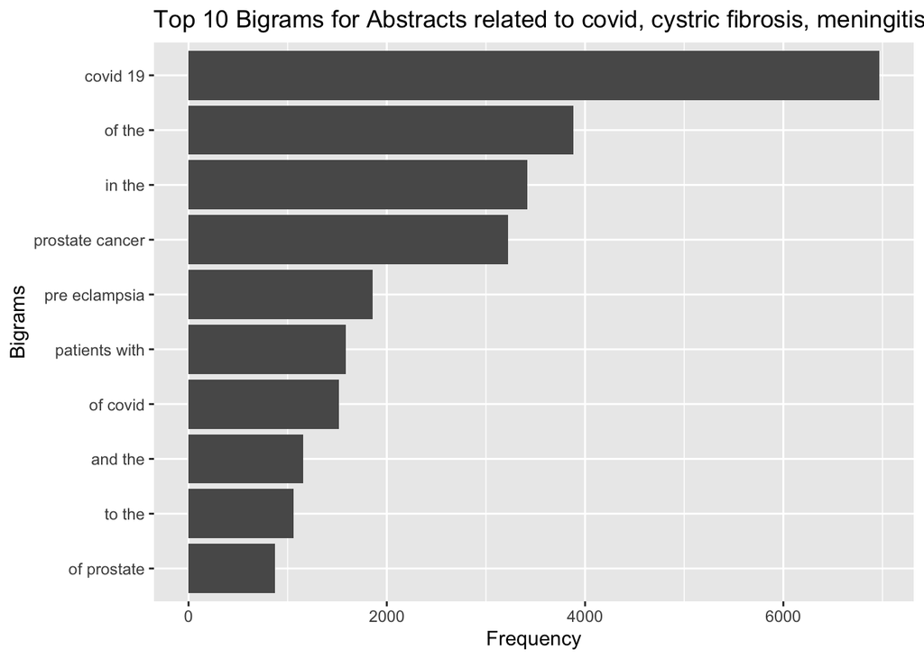

```r
options(repr.plot.width=12, repr.plot.height=8) # changing the size of this figure only


abstracts %>%
  unnest_tokens(word, abstract, token = "ngrams", n = 2) %>%
  count(word, sort = TRUE) %>%
  slice_max(n, n = 10) %>%
  ggplot(aes(x = n, y = fct_reorder(word, n))) +
  geom_col() +
  labs(x = "Frequency", y = "Bigrams", title = "Top 10 Bigrams for Abstracts related to covid, cystric fibrosis, meningitis, preeclampsia, and prostate cancer ")
```

3. Calculate the TF-IDF value for each word-search term combination (here you want the search term to be the “document”). What are the 5 tokens from each search term with the highest TF-IDF value? How are the results different from the answers you got in question 1?

The TF-IDF scores in this output reveal the importance of each word within each search term. For example the words with the top TF-IDF values for the prostate cancer search term are “prostate”, androgen”, “psa”, “postateectomy”, and “castration”, indicaitng the improance in using this temrinology in discussing prostate ccancer, but not as much in the topics related to the other search term.

This is more specific than identifying the top tokens per search term after removing stopwords in question 1. Question 1 only focuses on the raw counts and how often they appear after filtering. While these words relevant when discussing each term, they may not specifically reveal their importance, as TF-IDF scores give weights to terms that can appear often or not as much.

```r
tf_idf <-  abstracts %>%
  unnest_tokens(word, abstract) %>%
  count(term, word) %>%
  group_by(term) %>%
  bind_tf_idf(word, term, n) %>%
  arrange(desc(tf_idf)) %>%
  top_n(5, tf_idf)


kable(tf_idf, caption = "TF-IDF values for the Top 5 Words Per search Term")
```

TF-IDF values for the Top 5 Words Per search Term

| term | word | n | tf | idf | tf_idf |
| --- | --- | --- | --- | --- | --- |
| covid | covid | 7275 | 0.0371050 | 1.6094379 | 0.0597183 |
| prostate cancer | prostate | 3832 | 0.0311890 | 1.6094379 | 0.0501967 |
| preeclampsia | eclampsia | 2005 | 0.0142784 | 1.6094379 | 0.0229802 |
| preeclampsia | preeclampsia | 1863 | 0.0132672 | 1.6094379 | 0.0213527 |
| meningitis | meningitis | 429 | 0.0091942 | 1.6094379 | 0.0147974 |
| cystic fibrosis | cf | 625 | 0.0127188 | 0.9162907 | 0.0116541 |
| cystic fibrosis | fibrosis | 867 | 0.0176435 | 0.5108256 | 0.0090127 |
| cystic fibrosis | cystic | 862 | 0.0175417 | 0.5108256 | 0.0089608 |
| meningitis | meningeal | 219 | 0.0046935 | 1.6094379 | 0.0075539 |
| covid | pandemic | 800 | 0.0040803 | 1.6094379 | 0.0065670 |
| covid | coronavirus | 647 | 0.0032999 | 1.6094379 | 0.0053110 |
| meningitis | pachymeningitis | 149 | 0.0031933 | 1.6094379 | 0.0051394 |
| meningitis | csf | 206 | 0.0044149 | 0.9162907 | 0.0040453 |
| prostate cancer | androgen | 305 | 0.0024824 | 1.6094379 | 0.0039953 |
| prostate cancer | psa | 282 | 0.0022952 | 1.6094379 | 0.0036940 |
| meningitis | meninges | 106 | 0.0022718 | 1.6094379 | 0.0036562 |
| preeclampsia | pregnancy | 969 | 0.0069006 | 0.5108256 | 0.0035250 |
| covid | sars | 372 | 0.0018973 | 1.6094379 | 0.0030536 |
| preeclampsia | maternal | 797 | 0.0056757 | 0.5108256 | 0.0028993 |
| cystic fibrosis | cftr | 86 | 0.0017501 | 1.6094379 | 0.0028167 |
| prostate cancer | prostatectomy | 215 | 0.0017499 | 1.6094379 | 0.0028164 |
| covid | cov | 334 | 0.0017035 | 1.6094379 | 0.0027417 |
| cystic fibrosis | sweat | 83 | 0.0016891 | 1.6094379 | 0.0027184 |
| preeclampsia | gestational | 191 | 0.0013602 | 1.6094379 | 0.0021891 |
| prostate cancer | castration | 148 | 0.0012046 | 1.6094379 | 0.0019387 |

# Sentiment Analysis

1. Perform a sentiment analysis using the NRC lexicon. What is the most common sentiment for each search term? What if you remove “positive” and “negative” from the list?

The most common sentiment for each term is positive, with only meningitis and prostate cancer having negative sentiments. From this one could guess that the papers regarding covid-19, cystic fibrosis, and preeclampsia are studies that lead to positive outcomes for patients with these conditions, however this sentiment analysis on positive/negative terms isn’t intensive.

```r
abstracts %>%
  unnest_tokens(word, abstract) %>%
  inner_join(get_sentiments("nrc")) %>%
  group_by(term) |>
  summarise(sentiment = names(which.max(table(sentiment))))
```

```
# A tibble: 5 × 2
  term            sentiment
  <chr>           <chr>
1 covid           positive
2 cystic fibrosis positive
3 meningitis      negative
4 preeclampsia    positive
5 prostate cancer negative
```

```r
# doing the same but removing postive/negative from the lsit
nrc_fun <- get_sentiments("nrc")
nrc_fun <- nrc_fun[!nrc_fun$sentiment %in% c("positive","negative"), ]

abstracts %>%
unnest_tokens(word, abstract) %>%
inner_join(nrc_fun) %>%
group_by(term) |>
summarise(sentiment = names(which.max(table(sentiment))))
```

```
# A tibble: 5 × 2
  term            sentiment
  <chr>           <chr>
1 covid           fear
2 cystic fibrosis disgust
3 meningitis      fear
4 preeclampsia    anticipation
5 prostate cancer fear
```

2. Now perform a sentiment analysis using the AFINN lexicon to get an average positivity score for each abstract (hint: you may want to create a variable that indexes, or counts, the abstracts). Create a visualization that shows these scores grouped by search term. Are any search terms noticeably different from the others?

Most papers tend to have a negative positive score, however cystic fibrosis had an average positive score against the others (and with a much larger magnitude!). Without doing the PubMed search myself, my hope is that there is new advancements in cystic fibrosis mangment and treatment that are bieng shared, however a deeper sentimetn analysis is required.

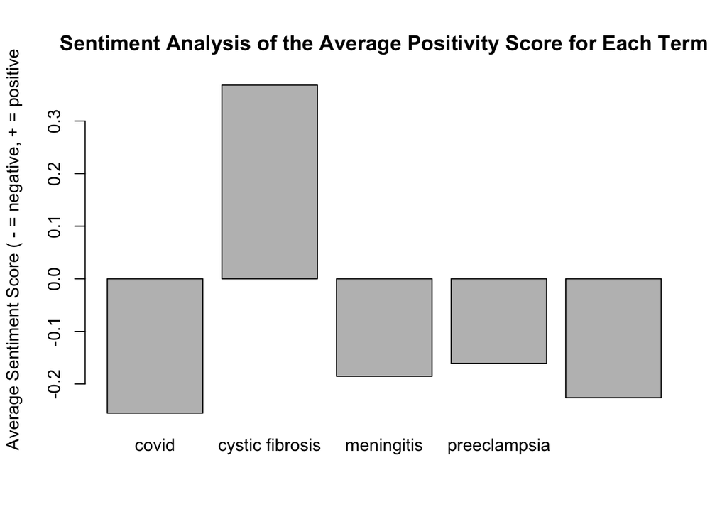

```r
options(repr.plot.width=12, repr.plot.height=8) # changing the size of this figure only

avg_by_abstract <- abstracts %>%
  unnest_tokens(word, abstract) %>%
  inner_join(get_sentiments("afinn"), by = "word") %>%
  group_by(term) %>%
  summarise(sentiment = mean(value, na.rm = TRUE))


barplot(avg_by_abstract$sentiment,
        names.arg = avg_by_abstract$term,
        main = "Sentiment Analysis of the Average Positivity Score for Each Term",
        ylab = "Average Sentiment Score ( - = negative, + = positive"

)
```